[figure not shown]

# Unsupervised Learning: AllLife Bank Customer Segmentation

## Project #6

# Context

AllLife Bank wants to focus on its credit card customer base in the next financial year. They have been advised by their marketing research team, that the penetration in the market can be improved. Based on this input, the Marketing team proposes to run personalized campaigns to target new customers as well as upsell to existing customers. Another insight from the market research was that the customers perceive the support services of the back poorly. Based on this, the Operations team wants to upgrade the service delivery model, to ensure that customer queries are resolved faster. Head of Marketing and Head of Delivery both decide to reach out to the Data Science team for help

# Objective

To identify different segments in the existing customer, based on their spending patterns as well as past interaction with the bank, using clustering algorithms, and provide recommendations to the bank on how to better market to and service these customers.

# Questions to Answer

1. How many different segments can the customers be grouped into?
2. What differentiates the segments from one another
3. What reccomendations can be derived from the data for each segment to improve marketing spend ROI

# Executive Summary of Analysis

## Conclusion

*Phone customers* prefer to handle their baning business verbally with a real person

*Online users* prefer to handle their banking with little or no bank personell participation online. They have the most credit cards and the highest average credit limit

The bank should make every effort to incentivize customers in the first two segments to the third. These customers actually interact witht he bank more but require less hands on assistance from bank personell.

## Recommendations

### Based on Heirarchical Clustering:

1. Customers in cluster 2 have the fewest credit cards. Bank should target customers (who are qualified) with additional creidt card services
2. Customers in cluster 0 use the online banking site the least. Bank should incentivise these customers to utilize online banking with training and possibly bonuses for using the site
3. Customer in cluster 1 are the banks best customers. Marketing to these customers shoul be focused on addtional credit cards services but maybe consider not marketing to this cluster of customers.

### Additional Recommendations:

1. The bank should tailor its contact method to meet the customers preference
   - Online users will probably prefer email notifications and offers
   - IRL users will probably prefer IRL contact or possible physical mailing offers. The bank should institute training for its employees, specifically bank tellers and managers to upsell credit card services to customers who are qualified and have low average credit available. Also they should offer assistance / training on how to use the online bank site to customers identified as using the online site the least
   - Phone customers should be encouraged to complete call surveys to understand why they prefer using the phone over the online web site or in person visits
2. Because both clustering methods resulted in similar findings either method could be used going forward
3. Bank should repeat analysis every six months using current data to monitor any migration of users from one cluster to another and proactively ensure that contact methods are updated appropriately for customers who do change clusters.

# Import Libraries

```python
# suppress warnings
import warnings
warnings.filterwarnings("ignore")

# primary data manipulation libraries
import pandas as pd
import numpy as np

# data visualization libraries
import matplotlib.pyplot as plt
import seaborn as sns
#import plotly.express as px

# remove number of displayed columns limit
pd.set_option("display.max_columns", None)

# set limit on the number of rows to display
pd.set_option("display.max_rows", 200)

# standard scaler function from the sklearn.preprocession libary
from sklearn.preprocessing import StandardScaler

# silhouette score function frtom the sklern.metrics library
from sklearn.metrics import silhouette_score

# c and p distance function from the scipy.spatial.distance library
from scipy.spatial.distance import cdist
from scipy.spatial.distance import pdist

# k-means clustering function for the sklearn.cluster library
from sklearn.cluster import KMeans

# silhoutte visualizer function from the yellowbrick.custer library
from yellowbrick.cluster import SilhouetteVisualizer

# functions for hierarchical clustering, compute cophenetic correlation, for creating dendrograms
from sklearn.cluster import AgglomerativeClustering
from scipy.cluster.hierarchy import dendrogram, linkage, cophenet

# animation functions from matplotlib and mpl_toolkits.mplot3d to animate the graph
from mpl_toolkits.mplot3d import axes3d, Axes3D
from matplotlib import animation
```

# Custom Functions Used in this Notebook

## histogram_boxplot

```python
# function to plot a boxplot and a histogram along the same scale.

def histogram_boxplot(data, feature, figsize=(12, 7), kde=False, bins=None):
    """
    Boxplot and histogram combined

    data: dataframe
    feature: dataframe column
    figsize: size of figure (default (12,7))
    kde: whether to the show density curve (default False)
    bins: number of bins for histogram (default None)
    """
    f2, (ax_box2, ax_hist2) = plt.subplots(
        nrows=2,  # Number of rows of the subplot grid= 2
        sharex=True,  # x-axis will be shared among all subplots
        gridspec_kw={"height_ratios": (0.25, 0.75)},
        figsize=figsize,
    )  # creating the 2 subplots
    sns.boxplot(
        data=data, x=feature, ax=ax_box2, showmeans=True, color="violet"
    )  # boxplot will be created and a star will indicate the mean value of the column
    sns.histplot(
        data=data, x=feature, kde=kde, ax=ax_hist2, bins=bins, palette="winter"
    ) if bins else sns.histplot(
        data=data, x=feature, kde=kde, ax=ax_hist2
    )  # For histogram
    ax_hist2.axvline(
        data[feature].mean(), color="green", linestyle="--"
    )  # Add mean to the histogram
    ax_hist2.axvline(
        data[feature].median(), color="black", linestyle="-"
    )  # Add median to the histogram
```

## Labeled_barplot

```python
# function to create labeled barplots

def labeled_barplot(data, feature, perc=False, v_ticks=True, n=None):
    """
    Barplot with percentage at the top

    data: dataframe
    feature: dataframe column
    perc: whether to display percentages instead of count (default is False)
    n: displays the top n category levels (default is None, i.e., display all levels)
    """

    total = len(data[feature])  # length of the column
    count = data[feature].nunique()
    if n is None:
        plt.figure(figsize=(count + 1, 5))
    else:
        plt.figure(figsize=(n + 1, 5))

    if v_ticks is True:
        plt.xticks(rotation=90, fontsize=15)

    ax = sns.countplot(
        data=data,
        x=feature,
        palette="Paired",
        order=data[feature].value_counts().index[:n].sort_values(),
    )

    for p in ax.patches:
        if perc == True:
            label = "{:.1f}%".format(
                100 * p.get_height() / total
            )  # percentage of each class of the category
        else:
            label = p.get_height()  # count of each level of the category

        x = p.get_x() + p.get_width() / 2  # width of the plot
        y = p.get_height()  # height of the plot

        ax.annotate(
            label,
            (x, y),
            ha="center",
            va="center",
            size=12,
            xytext=(0, 5),
            textcoords="offset points",
        )  # annotate the percentage

    plt.show()  # show the plot
```

## Plot_cdf

```python
# function to plot cdf for numeric values

def plot_cdf(num_cols):
    fig, axes = plt.subplots(3, 2, figsize=(20, 15))
    fig.suptitle("CDF plot of numerical variables", fontsize=20)
    counter = 0

    for i in range(3):
        sns.ecdfplot(ax=axes[i][0], x=df[num_cols[counter]])
        counter = counter + 1
        if counter != 5:
            sns.ecdfplot(ax=axes[i][1], x=df[num_cols[counter]])
            counter = counter + 1
        else:
            pass

    fig.tight_layout(pad=1.0)
```

## Visualize_outliers

```python
# funciton to visualize outliers for numeric values
def visualize_outliers(num_cols):
    plt.figure(figsize=(20,15))

    for i, variable in enumerate(num_cols):
        plt.subplot(2, 4, i + 1)
        plt.boxplot(df[variable], whis=1.5)
        plt.tight_layout()
        plt.title(variable)

    plt.show()
```

## Elbow_curve

```python
def elbow_curve(clusters, meanDistortions):
    plt.plot(clusters, meanDistortions, "bx-")
    plt.xlabel("k")
    plt.ylabel("Average Distortions")
    plt.title("Selecting k with the Elbow Method", fontsize=20)
```

## Hierarchical_cluster

```python
def hierarchical_cluster(distance_metrics, linkage_methods):
    high_cophenet_corr = 0
    high_dm_lm = [0, 0]

    for dm in distance_metrics:
        for lm in linkage_methods:
            Z = linkage(subset_scaled_df, metric=dm, method=lm)
            c, coph_dists = cophenet(Z, pdist(subset_scaled_df))
            print(f"Cophenetic correlation for {dm.capitalize()} distance and {lm} linkage is {c}.")

        if high_cophenet_corr < c:
            high_cophenet_corr = c
            high_dm_lm[0] = dm
            high_dm_lm[1] = lm

    # printing the combination of distance metric and linkage method with the highest cophenetic correlation
    print("")
    print(f"Highest cophenetic correlation is {high_cophenet_corr}, which is obtained with {high_dm_lm[0].capitalize()} distance and {high_dm_lm[1]} linkage.")
```

## Euc_linkage_analysis

```python
def euc_linkage_analysis(linkage_methods):
    high_cophenet_corr = 0
    high_dm_lm = [0, 0]

    for lm in linkage_methods:
        Z = linkage(subset_scaled_df, metric="euclidean", method=lm)
        c, coph_dists = cophenet(Z, pdist(subset_scaled_df))
        print("Cophenetic correlation for {} linkage is {}.".format(lm, c))

        if high_cophenet_corr < c:
            high_cophenet_corr = c
            high_dm_lm[0] = "euclidean"
            high_dm_lm[1] = lm

    # printing the combination of distance metric and linkage method with the highest cophenetic correlation
    print(f"Highest cophenetic correlation is {high_cophenet_corr}, which is obtained with {high_dm_lm[1]} linkage.")
```

## Dendograms

```python
def dendograms(linkage_methods):
    # list to save results of cophenetic correlation calculation
    compare = []

    # create a subplot image
    fig, axs = plt.subplots(len(linkage_methods), 1, figsize=(15, 30))

    # Enumerate through the list of linkage methods passed in
    # For each linkage method, we will plot a dendrogram and calculate the cophenetic correlation
    for i, method in enumerate(linkage_methods):
        Z = linkage(subset_scaled_df, metric="euclidean", method=method)

        dendrogram(Z, ax=axs[i])
        axs[i].set_title(f"Dendrogram ({method.capitalize()} Linkage)")

        coph_corr, coph_dist = cophenet(Z, pdist(subset_scaled_df))
        axs[i].annotate(f"Cophenetic\nCorrelation\n{coph_corr:0.2f}",(0.80, 0.80),xycoords="axes fraction")

        compare.append([method, coph_corr])
    return compare
```

```python
def mc_dendograms(distance_metrics, linkage_methods):
    fig, axs = plt.subplots(
        len(distance_metrics) + len(distance_metrics), 1, figsize=(10, 30)
    )

    i = 0
    for dm in distance_metrics:
        for lm in linkage_methods:
            Z = linkage(subset_scaled_df, metric=dm, method=lm)

            dendrogram(Z, ax=axs[i])
            axs[i].set_title("Distance metric: {}\nLinkage: {}".format(dm.capitalize(), lm))

            coph_corr, coph_dist = cophenet(Z, pdist(subset_scaled_df))
            axs[i].annotate(
                f"Cophenetic\nCorrelation\n{coph_corr:0.2f}",
                (0.80, 0.80),
                xycoords="axes fraction",
            )
            i += 1
```

# Load Data and Data Preprocessing

```python
df = pd.read_excel("credit_card_customer_data.xlsx", sheet_name="Sheet1", index_col="Sl_No")
```

```python
# print the shape of the dataset as number of rows and columns
print(f"There are {df.shape[0]} rows and {df.shape[1]} columns.")
```

```
There are 660 rows and 6 columns.
```

```python
# dataset information
df.info()
```

```
<class 'pandas.core.frame.DataFrame'>
Int64Index: 660 entries, 1 to 660
Data columns (total 6 columns):
 #   Column               Non-Null Count  Dtype
---  ------               --------------  -----
 0   Customer Key         660 non-null    int64
 1   Avg_Credit_Limit     660 non-null    int64
 2   Total_Credit_Cards   660 non-null    int64
 3   Total_visits_bank    660 non-null    int64
 4   Total_visits_online  660 non-null    int64
 5   Total_calls_made     660 non-null    int64
dtypes: int64(6)
memory usage: 36.1 KB
```

```python
df.columns = [c.replace(" ", "_") for c in df.columns]
```

```python
# Corrected Column Name Info
df.info()
```

```
<class 'pandas.core.frame.DataFrame'>
Int64Index: 660 entries, 1 to 660
Data columns (total 6 columns):
 #   Column               Non-Null Count  Dtype
---  ------               --------------  -----
 0   Customer_Key         660 non-null    int64
 1   Avg_Credit_Limit     660 non-null    int64
 2   Total_Credit_Cards   660 non-null    int64
 3   Total_visits_bank    660 non-null    int64
 4   Total_visits_online  660 non-null    int64
 5   Total_calls_made     660 non-null    int64
dtypes: int64(6)
memory usage: 36.1 KB
```

## Sample the data

```python
np.random.seed(1)
df.sample(n=10)
```

| Sl_No | Customer_Key | Avg_Credit_Limit | Total_Credit_Cards | Total_visits_bank | Total_visits_online | Total_calls_made |
| --- | --- | --- | --- | --- | --- | --- |
| 548 | 38125 | 26000 | 4 | 5 | 2 | 4 |
| 354 | 94437 | 9000 | 5 | 4 | 1 | 3 |
| 500 | 65825 | 68000 | 6 | 4 | 2 | 2 |
| 174 | 38410 | 9000 | 2 | 1 | 5 | 8 |
| 242 | 81878 | 10000 | 4 | 5 | 1 | 3 |
| 342 | 70779 | 18000 | 4 | 3 | 2 | 0 |
| 648 | 79953 | 183000 | 9 | 0 | 9 | 2 |
| 219 | 28208 | 19000 | 3 | 1 | 5 | 7 |
| 121 | 16577 | 10000 | 4 | 2 | 4 | 6 |
| 135 | 31256 | 13000 | 4 | 1 | 5 | 7 |

#### Observations:

1. SI_No is an index column and will be removed before analysis
2. Customer Key column was renamed to Customer_Key to be normalized with the other column names
3. Customer_Key is likely the Primary Key for the data in this dataset

### Check for null values in the data

```python
# precentage of missing values in columns
round(df.isna().sum() / df.isna().count() * 100, 2)
```

```
Customer_Key           0.0
Avg_Credit_Limit       0.0
Total_Credit_Cards     0.0
Total_visits_bank      0.0
Total_visits_online    0.0
Total_calls_made       0.0
dtype: float64
```

#### Observations

1. There are no null values in the data

### Check for duplicate values in the data

```python
df.duplicated().sum()
```

```
0
```

#### Observations:

1. There are no duplicate rows

### Statistics (before any data manipulation)

```python
df.describe().T
```

|  | count | mean | std | min | 25% | 50% | 75% | max |
| --- | --- | --- | --- | --- | --- | --- | --- | --- |
| Customer_Key | 660.0 | 55141.443939 | 25627.772200 | 11265.0 | 33825.25 | 53874.5 | 77202.5 | 99843.0 |
| Avg_Credit_Limit | 660.0 | 34574.242424 | 37625.487804 | 3000.0 | 10000.00 | 18000.0 | 48000.0 | 200000.0 |
| Total_Credit_Cards | 660.0 | 4.706061 | 2.167835 | 1.0 | 3.00 | 5.0 | 6.0 | 10.0 |
| Total_visits_bank | 660.0 | 2.403030 | 1.631813 | 0.0 | 1.00 | 2.0 | 4.0 | 5.0 |
| Total_visits_online | 660.0 | 2.606061 | 2.935724 | 0.0 | 1.00 | 2.0 | 4.0 | 15.0 |
| Total_calls_made | 660.0 | 3.583333 | 2.865317 | 0.0 | 1.00 | 3.0 | 5.0 | 10.0 |

## Preprocessing

### Customer_Key

As Customer_Key is suspected to be the primary key in the data set we need to check to see if the values in this field is found in multiple rows.

```python
gb_CK = df.groupby("Customer_Key").count()
gb_CK.loc[gb_CK.Total_calls_made >=2].shape[1]
```

```
5
```

```python
for k in list(gb_CK.loc[gb_CK.Total_calls_made >=2].index):
    display(df.loc[df["Customer_Key"] == k])
```

| Sl_No | Customer_Key | Avg_Credit_Limit | Total_Credit_Cards | Total_visits_bank | Total_visits_online | Total_calls_made |
| --- | --- | --- | --- | --- | --- | --- |
| 49 | 37252 | 6000 | 4 | 0 | 2 | 8 |
| 433 | 37252 | 59000 | 6 | 2 | 1 | 2 |

| Sl_No | Customer_Key | Avg_Credit_Limit | Total_Credit_Cards | Total_visits_bank | Total_visits_online | Total_calls_made |
| --- | --- | --- | --- | --- | --- | --- |
| 5 | 47437 | 100000 | 6 | 0 | 12 | 3 |
| 333 | 47437 | 17000 | 7 | 3 | 1 | 0 |

| Sl_No | Customer_Key | Avg_Credit_Limit | Total_Credit_Cards | Total_visits_bank | Total_visits_online | Total_calls_made |
| --- | --- | --- | --- | --- | --- | --- |
| 412 | 50706 | 44000 | 4 | 5 | 0 | 2 |
| 542 | 50706 | 60000 | 7 | 5 | 2 | 2 |

| Sl_No | Customer_Key | Avg_Credit_Limit | Total_Credit_Cards | Total_visits_bank | Total_visits_online | Total_calls_made |
| --- | --- | --- | --- | --- | --- | --- |
| 392 | 96929 | 13000 | 4 | 5 | 0 | 0 |
| 399 | 96929 | 67000 | 6 | 2 | 2 | 2 |

| Sl_No | Customer_Key | Avg_Credit_Limit | Total_Credit_Cards | Total_visits_bank | Total_visits_online | Total_calls_made |
| --- | --- | --- | --- | --- | --- | --- |
| 105 | 97935 | 17000 | 2 | 1 | 2 | 10 |
| 633 | 97935 | 187000 | 7 | 1 | 7 | 0 |

#### Observation:

There are 5 Customer_Key values that have muliple entries. From the FAQ for the assignement:

- "The 'Customer_Key' is a unique ID given to each customer in the database. The duplicate values might correspond to customer profile changes, and as such, there is no need to delete these records as these are actual occurrences at some point in the time. The column can be dropped during the analysis."

In each case where the same Customer_Key exists in the data, the lower SI_No has a lower number of credit cards. This suggests that the additional values represent the same customer but after they have accuired additional cards

There are zero occurences of a customer who has multiple entiries not contacting the bank on one form or another.

These are certainly NOT duplicate entries so they will not be removed from the dataset

## Univariate Analysis

### Avg_Credit_Limit

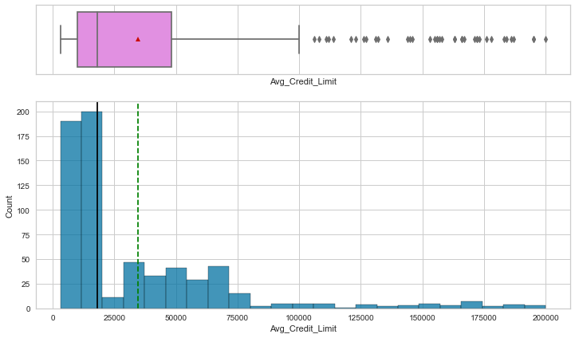

```python
histogram_boxplot(df,"Avg_Credit_Limit")
```

#### Observations:

1. Avg_Credit_Limit is right skewed
2. Looking at the data however and considering the huge span in credit limits, this doesn't suggest that the data that is an outlier is invalid or entered incorrectly
3. Nothing will be done to adjust for the outlier data

### Total_Credit_Cards

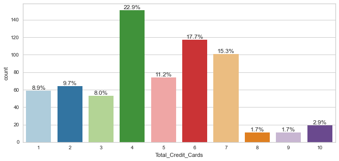

```python
labeled_barplot(df,"Total_Credit_Cards", True, False)
```

#### Observations:

1. 22.9% of customers have 4 credit cards
2. 93.7% of customers have 7 credit cards or less
3. 6.3% of customers have more that 7 credit cards
4. Only 8.9% of customers have only 1 credit card

### Total_visits_bank

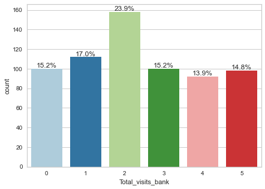

```python
labeled_barplot(df,"Total_visits_bank", True, False)
```

### Total_visits_online

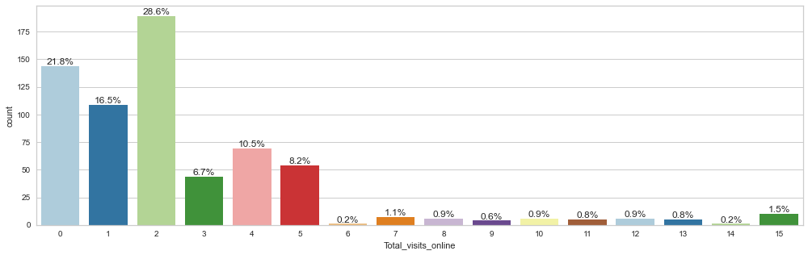

```python
labeled_barplot(df,"Total_visits_online", True, False)
```

### Total_calls_made:

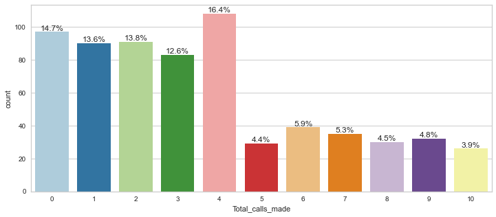

```python
labeled_barplot(df,"Total_calls_made", True, False)
```

#### Observations:

1. 14.7% of customers have never called the bank
2. 56.4% of customers have called the bank 1 - 4 times. 16.4% have called 4 times exactly
3. 28.8% of customers have called the bank more than 4 times
4. 3.9% of customers have called the bank 10 times!

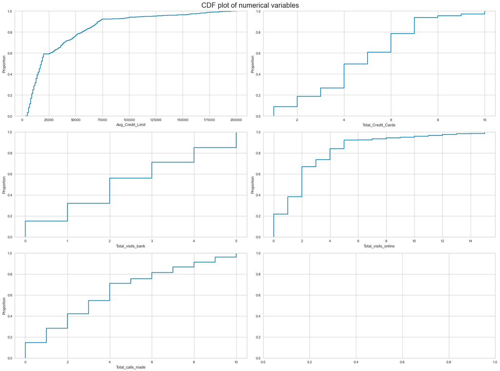

```python
# Generate plot of cdf of numnberical values in the data
num_cols = ["Avg_Credit_Limit", "Total_Credit_Cards", "Total_visits_bank", "Total_visits_online", "Total_calls_made"]
plot_cdf(num_cols)
```

## Bivariate Analysis

### Pairplot

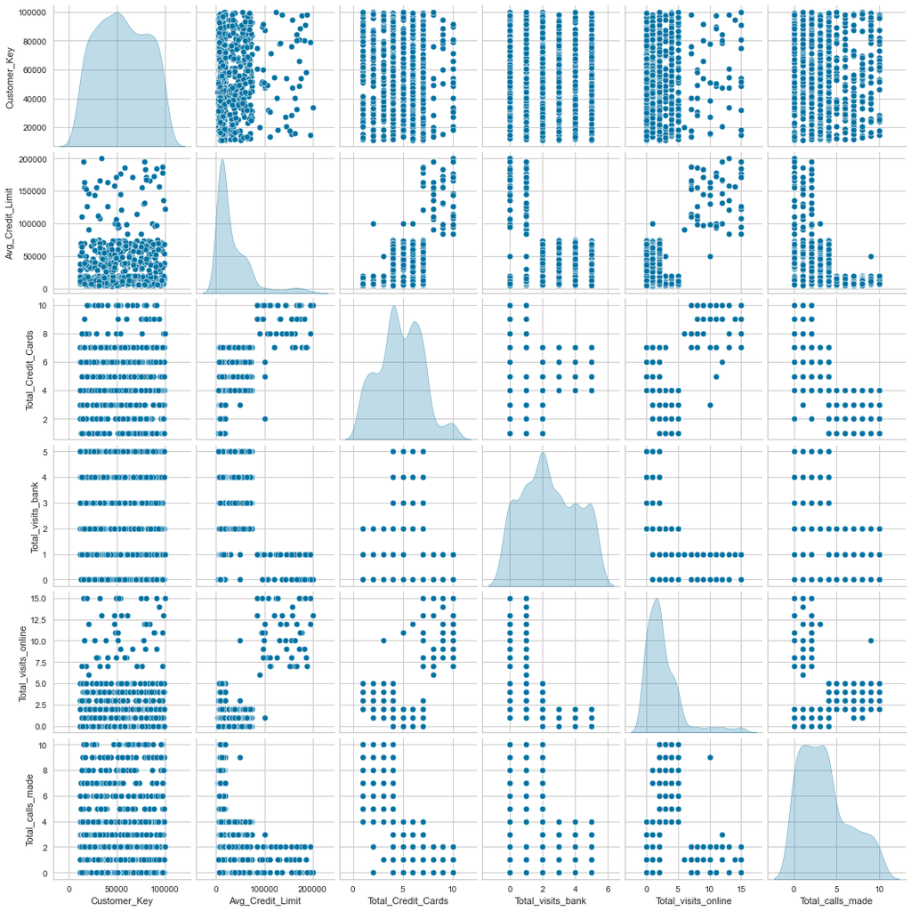

```python
sns.pairplot(df, diag_kind="kde");
```

### Heatmap

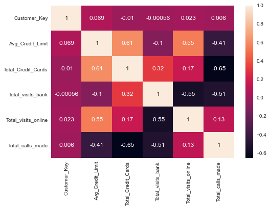

```python
sns.heatmap(df.corr(), annot=True);
```

#### Observations:

1. Average_Credit_Limit is negatively correlated to the Total_calls_made, and vistits to the bank but has a positive correlation to how many visits they make online.
2. Average_Credit_Cards has a negative correlation to the Total_calls_made but a positive corrlelation to both Total_visits_online (very small) and Total_visits_bank (almost 1/3 of the time)
3. As should be expected there is a strong positive correlation to the Total_Credit_Cards and the Avg_Credit_Limit
4. Customers who visit the bank are very unlikely to call or go online, however people who visit online may still call
5. Lower Average_Credit_Limit would suggest more phone calls and visits to the bank

## Outliers Treatment

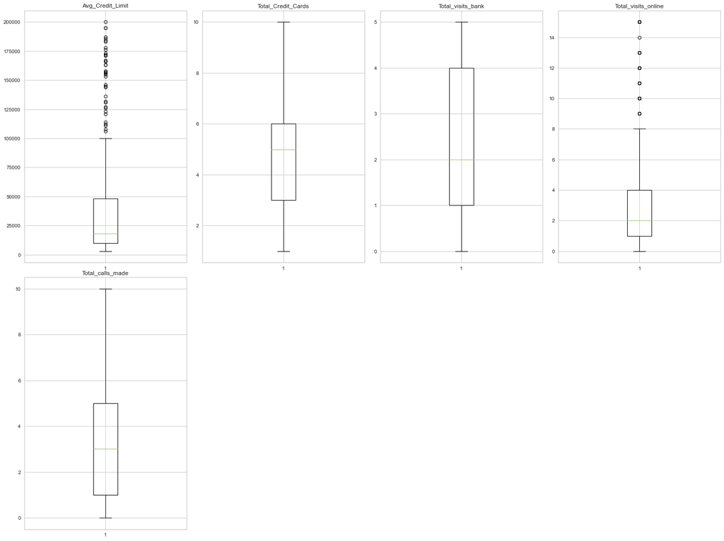

```python
visualize_outliers(num_cols)
```

#### Observations:

1. Avg_Credit_Limit and Total_visits_online have outliers.

As previously noted, Avg_Credit_Limit is expected to have outliers and nothing will be done to adjust for these outliers

Total_visits_online is highly correlated to Avg_Credit_Limit so because we are not doing anyhing abut the laters outliers we will not do anything with these outliers either

## Clustering

### Scale the Data

```python
scaler = StandardScaler()
subset = df.copy()
subset_scaled = scaler.fit_transform(subset)

subset_scaled_df = pd.DataFrame(subset_scaled, columns=subset.columns)
```

### K-Means Clustering

```python
# define the cluster range
clusters = range(1,10)
meanDistortions = []

# loop through the clusters
for k in clusters:
    model = KMeans(n_clusters=k)
    model.fit(subset_scaled_df)
    prediction = model.predict(subset_scaled_df)
    distortion = (
        sum(
            np.min(cdist(subset_scaled_df, model.cluster_centers_, "euclidean"), axis=1)
        )
        / subset_scaled_df.shape[0]
    )

    meanDistortions.append(distortion)

    print("Number of Clusters:", k, "\tAverage Distortion:", distortion)
```

```
Number of Clusters: 1 	Average Distortion: 2.2569539857353345
Number of Clusters: 2 	Average Distortion: 1.7858322163326599
Number of Clusters: 3 	Average Distortion: 1.505531485649799
Number of Clusters: 4 	Average Distortion: 1.363222352950455
Number of Clusters: 5 	Average Distortion: 1.2726936504945592
Number of Clusters: 6 	Average Distortion: 1.2193912912858786
Number of Clusters: 7 	Average Distortion: 1.179825674457407
Number of Clusters: 8 	Average Distortion: 1.1451767813291247
Number of Clusters: 9 	Average Distortion: 1.1236820903484583
```

### Plot an Elbow Curve

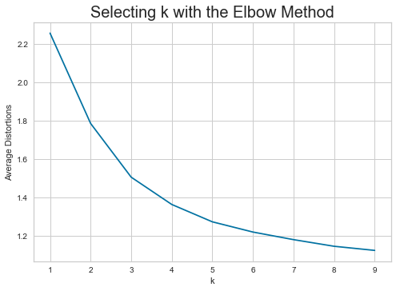

```python
elbow_curve(clusters, meanDistortions)
```

#### Observations:

1. The value for K of 2, 3 or 4 look to be where there are distinct "bends"

### Silhouette Scores

```python
silhouette_score_ls=[]
cluster_list = list(range(2, 10))

for n_clusters in cluster_list:
    clusterer = KMeans(n_clusters=n_clusters)
    preds = clusterer.fit_predict((subset_scaled_df))
    score = silhouette_score(subset_scaled_df, preds)
    silhouette_score_ls.append(score)
    print(f"For n_clusters = {n_clusters}, silhouette score is {score}")
```

```
For n_clusters = 2, silhouette score is 0.33817196365464486
For n_clusters = 3, silhouette score is 0.4177434852377372
For n_clusters = 4, silhouette score is 0.3228907072652812
For n_clusters = 5, silhouette score is 0.2850863954249504
For n_clusters = 6, silhouette score is 0.25422115827085306
For n_clusters = 7, silhouette score is 0.23792038836677282
For n_clusters = 8, silhouette score is 0.22756918030422235
For n_clusters = 9, silhouette score is 0.20845415560877475
```

### Plot Silhouette Score

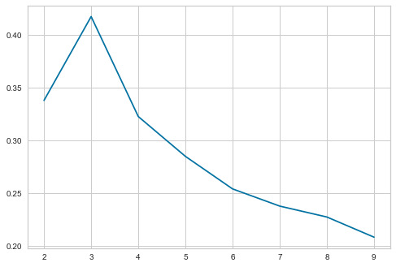

```python
plt.plot(cluster_list, silhouette_score_ls)
```

#### Observations:

1. The chart suggest that 3 clusters is the optimal number becuase it gives us the highers Silhouette score (.4177)
2. 2 and 4 clusters are so far away in score from 3 (.0796 and .0949 resectively) that they simply are not viable options

### Optimal Number Of Clusters

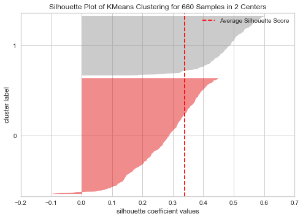

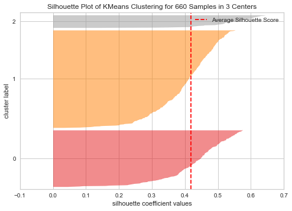

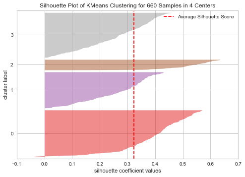

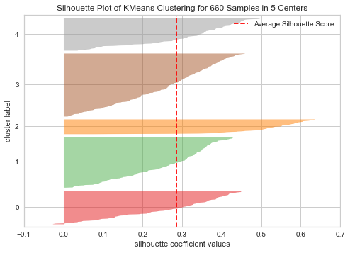

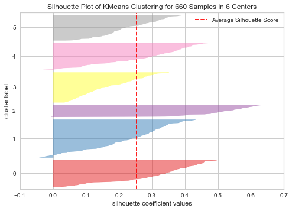

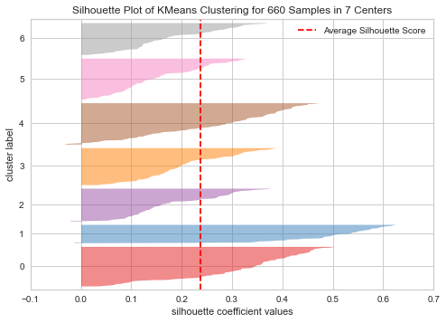

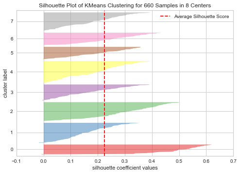

```python
# find the optimal number of clusters with silhouette coefficients

num_list = list(range(2,9))
for num in num_list:
    visualizer = SilhouetteVisualizer(KMeans(num, random_state=1))
    visualizer.fit(subset_scaled_df)
    visualizer.show()
```

#### Observations:

1. The silhouette score and the Visualizer graphs tell us that 3 appears to be the correct value for K

### K-Means for 3 clusters

```python
# fit for 3 clusters only
kmeans = KMeans(n_clusters=3, random_state=1)
kmeans.fit(subset_scaled_df)

df["KM_Clusters"] = kmeans.labels_

cluster_mean = df.groupby("KM_Clusters").mean()

# Get counts for each cluster
cluster_mean["count_in_each_segment"] = (df.groupby("KM_Clusters")["Customer_Key"].count().values)

# Output the cluster_mean
cluster_mean.style.highlight_max(color="blue", axis=0)
```

| KM_Clusters | Customer_Key | Avg_Credit_Limit | Total_Credit_Cards | Total_visits_bank | Total_visits_online | Total_calls_made | count_in_each_segment |
| --- | --- | --- | --- | --- | --- | --- | --- |
| 0 | 55239.830357 | 12174.107143 | 2.410714 | 0.933036 | 3.553571 | 6.870536 | 224 |
| 1 | 54881.329016 | 33782.383420 | 5.515544 | 3.489637 | 0.981865 | 2.000000 | 386 |
| 2 | 56708.760000 | 141040.000000 | 8.740000 | 0.600000 | 10.900000 | 1.080000 | 50 |

#### Observations:

##### Cluster 2

1. Has the highest value for 3 of the key fields (Customer_Key is ignored), Avg_Credit_Limt, Total_Credit_Cards, and Total_visits_online.
2. Has the lowest value for Total_visits_bank
3. Has the fewest number of entries

##### Cluster 1

1. Has the highest value for Total_visits_bank
2. Has the lowest value for Total_visits_online
3. Has the higher number of entries

##### Cluster 0

1. Has the highest value for Total_calls_mae
2. Has the lowest value for Avg_Credit_Limit and Total_Credit_Cards

### Visualization of the clusters

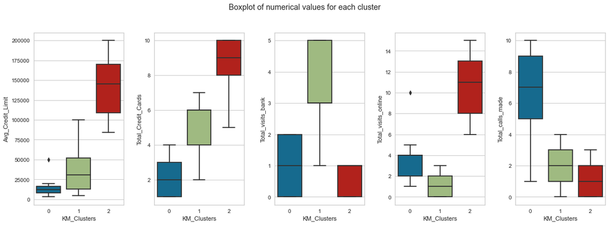

```python
# boxplot for numerical values in each cluster
fig, axes = plt.subplots(1, 5, figsize=(16,6))
fig.suptitle("Boxplot of numerical values for each cluster")
counter = 0
for i in range(5):
    sns.boxplot(ax=axes[i], y=df[num_cols[counter]], x=df["KM_Clusters"])
    counter += 1

fig.tight_layout(pad=2.0)
```

#### Observations:

##### Cluster 0

This cluster includes customers who:

1. have an average credit limit under 25,000
2. have the fewest numnber of cards (1 - 4 max)
3. visit the physical bank rarely (0 - 2 times)
4. visit the online bank occaionally (1 - 5 times)
5. make the most phone calls to the bank (4 - 10 times)

### Hierarchical Clustering

```python
# Distance Metrics
distance_metrics = ["euclidean", "chebyshev", "mahalanobis", "cityblock"]

# Linkage Methods
linkage_methods = ["single", "complete", "average", "weighted"]

hierarchical_cluster(distance_metrics, linkage_methods)
```

```
Cophenetic correlation for Euclidean distance and single linkage is 0.715826147503084.
Cophenetic correlation for Euclidean distance and complete linkage is 0.8333358686900459.
Cophenetic correlation for Euclidean distance and average linkage is 0.8684228720933057.
Cophenetic correlation for Euclidean distance and weighted linkage is 0.8642251666438747.
Cophenetic correlation for Chebyshev distance and single linkage is 0.6993328509872334.
Cophenetic correlation for Chebyshev distance and complete linkage is 0.7832281429250633.
Cophenetic correlation for Chebyshev distance and average linkage is 0.8628342866871905.
Cophenetic correlation for Chebyshev distance and weighted linkage is 0.8345913036690694.
Cophenetic correlation for Mahalanobis distance and single linkage is 0.6829750720107937.
Cophenetic correlation for Mahalanobis distance and complete linkage is 0.6051316784974621.
Cophenetic correlation for Mahalanobis distance and average linkage is 0.7754307051655686.
Cophenetic correlation for Mahalanobis distance and weighted linkage is 0.7777104249754612.
Cophenetic correlation for Cityblock distance and single linkage is 0.7109246213997495.
Cophenetic correlation for Cityblock distance and complete linkage is 0.8375342776656125.
Cophenetic correlation for Cityblock distance and average linkage is 0.8648270854737592.
Cophenetic correlation for Cityblock distance and weighted linkage is 0.8583676558565547.

Highest cophenetic correlation is 0.8642251666438747, which is obtained with Euclidean distance and weighted linkage.
```

### Analyze different linkage methods for Euclidiean distance

```python
linkage_methods = ["single", "complete", "average", "centroid", "ward", "weighted"]
euc_linkage_analysis(linkage_methods)
```

```
Cophenetic correlation for single linkage is 0.715826147503084.
Cophenetic correlation for complete linkage is 0.8333358686900459.
Cophenetic correlation for average linkage is 0.8684228720933057.
Cophenetic correlation for centroid linkage is 0.8656427328161594.
Cophenetic correlation for ward linkage is 0.7067190998109724.
Cophenetic correlation for weighted linkage is 0.8642251666438747.
Highest cophenetic correlation is 0.8684228720933057, which is obtained with average linkage.
```

#### Observations:

1. Euclidean distance and average linkage of 0.8684 provides the maximum Cophenetic Correlation

### Dendograms of the different linkage methods

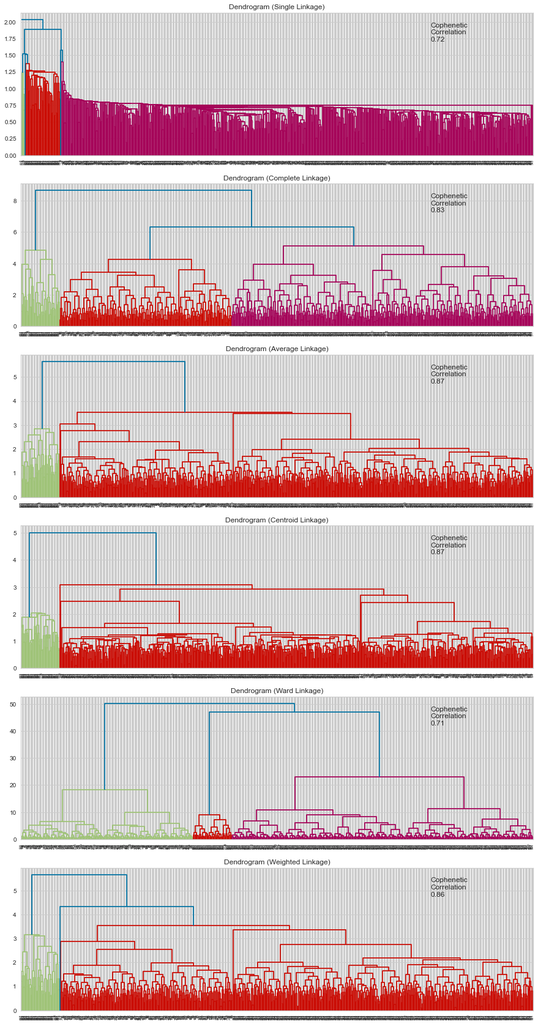

```python
compare_cols = ["Linkage", "Cophenetic Coefficient"]

compare = dendograms(linkage_methods)
```

#### Observations:

1. The Dendrogram for Ward linkage shows distinct and separate clustes and the lowest Cophenetic Correlation

### Compare Cophenetic Correlations

```python
# Create a new dataframe for this process

df_cc = pd.DataFrame(compare, columns=compare_cols)
df_cc
```

|  | Linkage | Cophenetic Coefficient |
| --- | --- | --- |
| 0 | single | 0.715826 |
| 1 | complete | 0.833336 |
| 2 | average | 0.868423 |
| 3 | centroid | 0.865643 |
| 4 | ward | 0.706719 |
| 5 | weighted | 0.864225 |

### Dendorgram Graph for Mahalanobis and CityBlock distances with weighted and average linkage methods

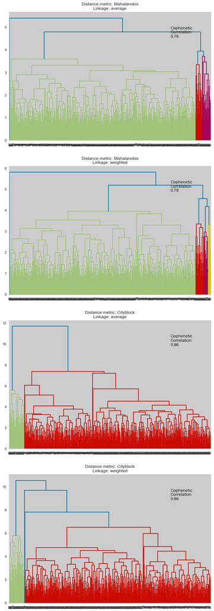

```python
distance_metrics = ["mahalanobis", "cityblock"]
linkage_methods = ["average", "weighted"]

# centroid was also high, but can only be created using Euclidean distance so it is skipped here

mc_dendograms(distance_metrics, linkage_methods)
```

#### Observations:

1. of all the dendrograms generated Ward linkage shows the ost distinct clusters and has the lowest Cophenetic Correlation
2. All the dendrograms show at least 3 clusters clearly

### Current Silhouette Scores

```python
silhouette_score_hc = []
cluster_list = list(range(2, 10))
for n_clusters in cluster_list:
    clusterer = AgglomerativeClustering(n_clusters=n_clusters)
    preds = clusterer.fit_predict((subset_scaled_df))
    score = silhouette_score(subset_scaled_df, preds)
    silhouette_score_hc.append(score)
    print("For n_clusters = {}, silhouette score is {}".format(n_clusters, score))
```

```
For n_clusters = 2, silhouette score is 0.33811250832687806
For n_clusters = 3, silhouette score is 0.41782525470042764
For n_clusters = 4, silhouette score is 0.31213889088706714
For n_clusters = 5, silhouette score is 0.2729797232608641
For n_clusters = 6, silhouette score is 0.2382147994519145
For n_clusters = 7, silhouette score is 0.20973866896049975
For n_clusters = 8, silhouette score is 0.19754523680023992
For n_clusters = 9, silhouette score is 0.17604761610726194
```

### Graph of Silhouette Scores

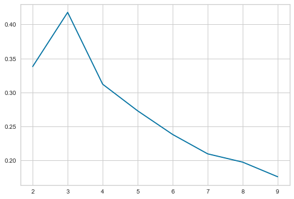

```python
plt.plot(cluster_list, silhouette_score_hc)
```

#### Observations:

1. 3 Clusters gives us the highest score and still appears to be the optimal number of clusters

## Agglomerative Clustering

```python
# 3 clusters with euclidean affinity and average linkage only

HCmodel = AgglomerativeClustering(n_clusters=3, affinity="euclidean", linkage="average")
HCmodel.fit(subset_scaled_df)

# add HC cluster labels to the original dataframe
df["HC_Clusters"] = HCmodel.labels_

cluster_profile = df.groupby("HC_Clusters").mean()

cluster_profile["count_in_each_segments"] = (df.groupby("HC_Clusters")["Customer_Key"].count().values)

# let"s display cluster profiles
cluster_profile.style.highlight_max(color="red", axis=0)
```

| HC_Clusters | Customer_Key | Avg_Credit_Limit | Total_Credit_Cards | Total_visits_bank | Total_visits_online | Total_calls_made | KM_Clusters | count_in_each_segments |
| --- | --- | --- | --- | --- | --- | --- | --- | --- |
| 0 | 54874.821705 | 33736.434109 | 5.511628 | 3.485788 | 0.987080 | 2.005168 | 0.997416 | 387 |
| 1 | 56708.760000 | 141040.000000 | 8.740000 | 0.600000 | 10.900000 | 1.080000 | 2.000000 | 50 |
| 2 | 55252.730942 | 12156.950673 | 2.403587 | 0.928251 | 3.556054 | 6.883408 | 0.000000 | 223 |

#### Observations:

##### Cluster 2

This cluster has:

1. the highest Total_calls_made

##### Cluster 1

This cluster has:

1. the highest Avg_Credit_Limit, Total_Credit_Cards and Total_Visits_Online
2. the lowest Total_calls_made

##### Cluster 0

This cluster has:

1. the highest Total_visits_bank
2. the lowestl Total_visits_online

## Visualizations of the Clusters

### Boxplots

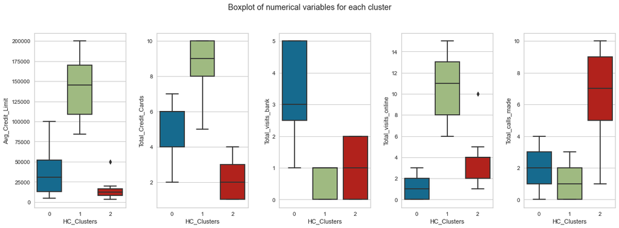

```python
fig, axes = plt.subplots(1, 5, figsize=(16, 6))
fig.suptitle("Boxplot of numerical variables for each cluster")
counter = 0
for i in range(5):
    sns.boxplot(ax=axes[i], y=df[num_cols[counter]], x=df["HC_Clusters"])
    counter = counter + 1

fig.tight_layout(pad=2.0)
```

#### Observations:

##### Cluster 1

This cluster has customers who:

- have average credit limit above 75,000
- have the most credit cards, between 5 - 10
- visit the bank the least, 0 - 1 times
- visit the banks online site the most, 6 - 15 times
- make the least number of calls to the bank, 0-2 times

### Compare K Means and Heirarchical Clustering

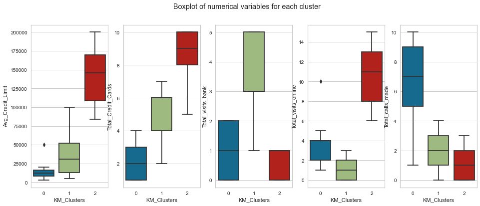

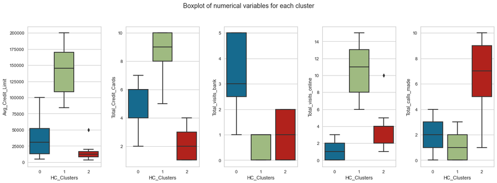

```python
fig, axes = plt.subplots(1, 5, figsize=(16, 6))
fig.suptitle("Boxplot of numerical variables for each cluster")
counter = 0
for i in range(5):
    sns.boxplot(ax=axes[i], y=df[num_cols[counter]], x=df["KM_Clusters"])
    counter = counter + 1

# boxplot for numerical variables in each cluster
fig, axes = plt.subplots(1, 5, figsize=(16, 6))
fig.suptitle("Boxplot of numerical variables for each cluster")
counter = 0
for i in range(5):
    sns.boxplot(ax=axes[i], y=df[num_cols[counter]], x=df["HC_Clusters"])
    counter = counter + 1

fig.tight_layout(pad=2.0)
```

### Compate Silhouette Scores

```python
comparison_frame = pd.DataFrame({"Clusters":["2","3","4","5","6",
                                          "7","8","9"],
                                          "KMeans Score": silhouette_score_ls, "HC Scores": silhouette_score_hc
                                         })
comparison_frame
```

|  | Clusters | KMeans Score | HC Scores |
| --- | --- | --- | --- |
| 0 | 2 | 0.338172 | 0.338113 |
| 1 | 3 | 0.417743 | 0.417825 |
| 2 | 4 | 0.322891 | 0.312139 |
| 3 | 5 | 0.285086 | 0.272980 |
| 4 | 6 | 0.254221 | 0.238215 |
| 5 | 7 | 0.237920 | 0.209739 |
| 6 | 8 | 0.227569 | 0.197545 |
| 7 | 9 | 0.208454 | 0.176048 |

#### Observations:

1. Both methods recommend 3 clusters
2. Customers with high credit limits and more credit cards are identified as the prime subject for future marketing effort
3. Silhouette scores are very similar for both methods
4. The different clustering methods did group the customers slightly differently